# Corpus Keyness

Matthew Lincoln

3/16/2020

### Corpus Size

The total corpus size is 5273

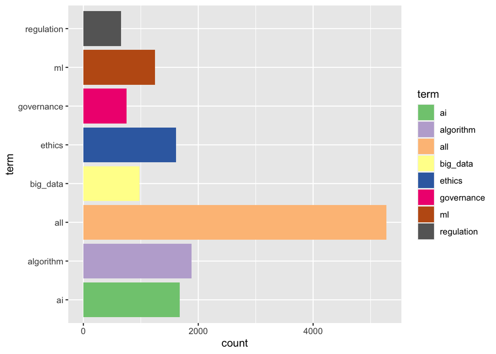

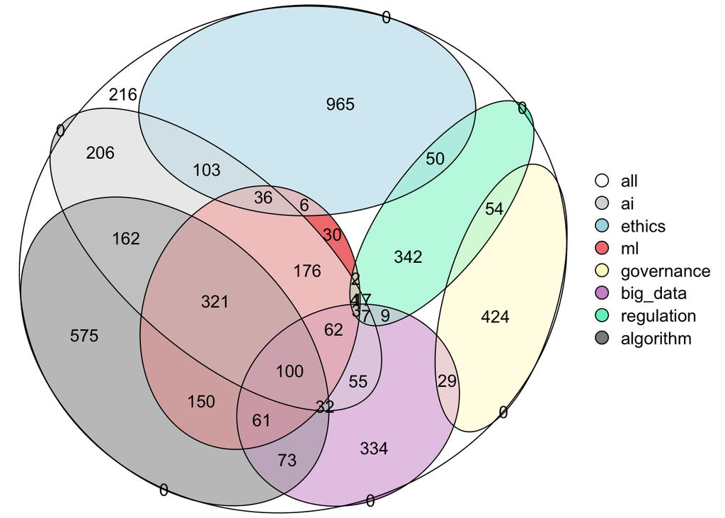

## Keyness

Keyness calculates the likelihood ratio of a word appearing in a subset of documents from a corpus compared to the overall distribution of that term in all the documents of the corpus. The following visualizaitions show the the top 20 distinctive words for each subset of the corpus, ranked by the effect size (i.e. just how much more disporportionately the word appears in the subset versus the entire corpus.)

For example, in `ai_ethics_docs` below, “singularity”, “sci-fi”, “weapons” are significantly more likely to appear in documents that contain both “artificial intelligence” and “ethics/ethical” compared to all other documents. Meanwhile, `ai_no_ethics_docs` - docs that metion AI but do *not* mention “ethics/ethical”, metion “chatbots”, “ai-powered”, “personalization” etc. far more than the full corpus.

|  | ai_ethics_docs | ai_no_ethics_docs | ai_governance_docs | ai_no_governance_docs | ml_ethics_docs | ml_no_ethics_docs | ethics_only_docs |
| --- | --- | --- | --- | --- | --- | --- | --- |
| 1 | weapons | alphago | ocean | chatbots | universities | scikit-learn | shame |
| 2 | singularity | chatbots | non | chatbot | singularity | logistic | virtue |
| 3 | sci-fi | reinforcement | oracle | alphago | facial | ml | unethical |
| 4 | nuclear | recurrent | lawyers | openai | japanese | ensemble | guilty |
| 5 | robots | chatbot | un | ais | biases | algebra | morally |
| 6 | alan | ai-powered | hi | conversational | alan | numpy | happiness |
| 7 | technologists | conversational | storm | deepmind | ai-based | descent | charity |
| 8 | robot | ml | universities | ai-based | microsoft's | regression | sexual |
| 9 | existential | recommends | * | robotic | existential | overfitting | harassment |
| 10 | humanity | chess | organisations | ai-driven | disciplines | jupyter | moral |

[output cut: 25 more lines]

## Keywords in context

Here’s a sample of the top keywords from the “AI & Ethics” subset of the corpus. If this seems useful, we can set it up to run on Shiny so you can punch in any keyword you want.

|  | docname | prhases |
| --- | --- | --- |
| 1 | https://ayearofai.com/rohan-2-time-progress-ae804fa86cca | Keep updated on progress in Deep Learning here . III . The Future Could a singularity , the result of an intelligence explosion , be right around the corner ? -groups . Us in the light of strong super… |
| 2 | https://becominghuman.ai/how-ethical-is-artificial-intelligence-37ee034e7435 | Michio Kaku is not so gloomy about the prospects ; he doesn't expect a technological singularity ( a time when AI becomes smarter than humans ) anytime soon . Kaku isattention , others are more futuri… |
| 3 | https://becominghuman.ai/the-ethical-questions-raised-by-artificial-intelligence-1219e3295b50 | hope for . I'm of the opinion that if we were to create a technical singularity , in the form of hyper sentience , it would actually be for the good) but I fear that capability is impossible to achiev… |
| 4 | https://blog.prototypr.io/googleduplex-2bb2de24674a | and Artificial Intelligence Should robots sound like Humans ? Google Duplex and the Point of Singularity This week Google introduced its new ( and impressive ) artificial intelligence project called G… |
| 5 | https://feed.itsrio.org/in-defense-of-an-anthropophagic-artificial-intelligence-8e790d86a4e5 | . I especially appreciate - as a committed Deleuzian - his instructions to forget the Singularity and think multiplicity . Not a single algorithm at the end of History , but |
| 6 | https://journalofbeautifulbusiness.com/its-time-for-beautiful-ai-and-no-it-is-not-human-centered-a37f8544b2dd | accept into our " circle of kinship . " Such Indigenous AI honors multiplicity over singularity , a non-linear over a linear concept of time ( and progress ) , interiority |
| 7 | https://medium.com/@coderoshi/its-just-artificial-intelligence-3dd5bd5cbcbc | in worlds of malevolent machine superintelligences , from The Matrix to Terminator . While technological singularity is possible , there are subtler economic concerns that don't depend on the bleak co… |
| 8 | https://medium.com/@fruzse/actually-it-s-about-ethics-in-self-driving-cars-58d2c2fd78d7 | . Kaplan says this scenario - of robots becoming self-aware , known as " the singularity " - won't happen how we tend to imagine it , if it even happens |
| 9 | https://medium.com/@HollyKnowlman/ethical-considerations-for-practical-ai-applications-42dee046ca7c | algorithms into our rec rooms and kitchens , the end of privacy ? Is the Singularity imminent ? " - Mark Kingwell ( Artificial Intelligence in 2017 ) And yep , |
| 10 | https://medium.com/@jelmerevers/artificial-intelligence-and-education-moving-beyond-the-hype-6df3d644ef7a | an excel sheet on steroids . Some , like Ray Kurzweil , point towards the Singularity when we reach real Artificial Intelligence . Just like a gravitational singularity where gravitational tidalpoint … |

[output cut: 19 more lines]

|  | docname | prhases |
| --- | --- | --- |
| 1 | https://becominghuman.ai/ai-can-be-made-ethical-if-people-behind-it-are-ethical-455bd54ba39 | AGI ) called the Sibyl System . It governs everyone's crime coefficient , aptitudes , weapons , and law . Just like the theme with any other sci-fi dystopian drama ,UNESCO , research such as human clo… |
| 2 | https://becominghuman.ai/how-ethical-is-artificial-intelligence-37ee034e7435 | payload , an ethical issue which is being contested by the Net-Neutrality drive . Autonomous weapons have also started to emerge from defense research . However , a dumb technology without |
| 3 | https://blog.usejournal.com/nextgengov-the-big-boring-bureaucratic-revolution-d5dc78e53b1c | and investigating armed conflicts and environmental destruction . Others warn of the dangers of autonomous weapons , risk of biohacking as rising number of people depend on wearable technology , syste… |
| 4 | https://feed.itsrio.org/in-defense-of-an-anthropophagic-artificial-intelligence-8e790d86a4e5 | with missiles ; the most important battle is happening in another field and with other weapons … " . However , what struck me the most was something little discussed in |
| 5 | https://greenonions.com/ux-in-the-age-of-abusability-797cd01f6b13 | , hacking ) . But the new age of abusability turns seemingly innocent products into weapons . My hypothesis : We can prevent abusability by looking at the team's composition , |
| 6 | https://medium.com/@benbendc/celebrating-ethically-aligned-design-and-the-humans-who-wrote-it-62e5e8cc038d | their emphasis on ethics , values , and human norms . The section on Autonomous Weapons Systems is also strong in its commitment to human-centered design : Autonomy in functions such |
| 7 | https://medium.com/@coderoshi/its-just-artificial-intelligence-3dd5bd5cbcbc | better troops by improving training systems , creating novel curricula for war games . Smart weapons and better intelligence , along with more pedestrian benefits of industry , like optimizing logisti… |
| 8 | https://medium.com/@cruizgomez/telecommunications-high-tech-connected-car-week-02-2019-b57a3ed1c4d0 | of cyberthreats , the widespread increase in surveillance cases , and the development of autonomous weapons . Moreover , they don't trust the government or any of its agencies to regulate |
| 9 | https://medium.com/@dan.jeffries/coronavirus-a-reason-for-hope-d88ac9a265f3 | us all ( see Occam's Razor and the fact that we have pinpoint precision smart weapons that kill precisely rather than randomly . ) At this point it's not clear which |
| 10 | https://medium.com/@dpatil/a-code-of-ethics-for-data-science-cda27d1fac1 | stereotypes . And my friend Cathy O'Neil documents many more cases in her great book Weapons of Math Destruction . Let's not forget about people stealing our data . From healthcare |

[output cut: 49 more lines]

|  | docname | prhases |
| --- | --- | --- |
| 1 | https://ayearofai.com/rohan-2-time-progress-ae804fa86cca | the objective to do so , superintelligence could cause an " intelligence explosion " . Sci-fi author Vernor Vinge first referred to this as what many of you may have heard |
| 2 | https://becominghuman.ai/ai-can-be-made-ethical-if-people-behind-it-are-ethical-455bd54ba39 | , aptitudes , weapons , and law . Just like the theme with any other sci-fi dystopian drama , the AGI repeatedly fails to perceive complex human sentiments ; chaos is |
| 3 | https://becominghuman.ai/how-ethical-is-artificial-intelligence-37ee034e7435 | synopsis of " Be right back " , an episode of Black Mirror - a sci-fi TV series that grotesquely portrays humanity's obsession with technology . Most episodes are set in |
| 4 | https://blog.usejournal.com/nextgengov-the-big-boring-bureaucratic-revolution-d5dc78e53b1c | technologies on human rights and law . Conversely , we find subject experts resorting to sci-fi to reimagine new mechanisms of governance . We are on the lookout for more examplesWe are on the lookout… |
| 5 | https://howwegettonext.com/the-black-mirror-writers-room-teaching-technology-ethics-through-speculation-f1a9e2deccf4 | Can a robot hold a copyright ? If you want to use this piece of sci-fi , here is the slide deck that I've been using to propose these questions ;be less compelling - which is perhaps why the " evil te… |
| 6 | https://medium.com/@codepo8/artificial-intelligence-for-more-human-interfaces-765a21a40cd2 | your computer in a hands-free environment like driving or cooking . It gives computers this Sci-Fi " genie on demand " feeling . There is no interface to learn - just |
| 7 | https://medium.com/@dan.jeffries/coronavirus-a-reason-for-hope-d88ac9a265f3 | virus is mutating rapidly ( no credible evidence to support that because this isn't a sci-fi movie where viruses mutate overnight , though it could happen in time ) or thatWe have the capacity to move… |
| 8 | https://medium.com/@Francesco_AI/machine-ethics-and-artificial-moral-agents-85ad6b71d40b | or worst invention ever . The chance of robots taking over and the following catastrophic sci-fi scenario makes the ethical and purposeful design of machines and algorithms not simply important but |
| 9 | https://medium.com/@fruzse/actually-it-s-about-ethics-in-self-driving-cars-58d2c2fd78d7 | robots - in this case , self-driving vehicles - sounds like something out of a sci-fi feature , and not something practical and tangible that is needed right now , likeit is predicted 10 million self-… |
| 10 | https://medium.com/@ReasonDigital/screw-tech-ethics-9dfa6dce8097 | this debate , ironically , poses a risk of doing an unintended harm itself . Sci-fi writer and Futurist Arthur C . Clarke famously said that " Any sufficiently advanced technology |

[output cut: 19 more lines]

|  | docname | prhases |
| --- | --- | --- |
| 1 | https://becominghuman.ai/ai-can-be-made-ethical-if-people-behind-it-are-ethical-455bd54ba39 | to their un-ethical nature with respect to human values [ 9 ] . Matters involving nuclear weapons are dealt with utmost importance . Similarly , strict international laws ( or guidelines |
| 2 | https://becominghuman.ai/how-ethical-is-artificial-intelligence-37ee034e7435 | pointed out , why no artificially intelligent robots were successfully deployed to contain the Fukushima Nuclear Disaster . Evidently , future jobs will be more complex and cognitively challenging ; t… |
| 3 | https://medium.com/@EthanZ/training-the-next-generation-of-ethical-techies-6269d92f92b8 | evaluates clean energy and carbon capture technologies , but has also written on topics from nuclear disarmament to autonomous vehicles . His PhD work is on Bose-Einstein condensate , a strange |
| 4 | https://medium.com/@foundersfund/understanding-artificial-intelligence-317ae9435b8c | advanced AI is inevitable then the only real variable is its timing . Just as nuclear weapons would have been less dangerous in a world without ICBMs , there are safety |
| 5 | https://medium.com/@marksstorm/random-finds-2017-week-43-on-how-ai-might-take-over-the-world-big-data-meets-big-brother-and-913e9d336306 | same reason that many of the world's top physicists joined the Manhattan Project to develop nuclear weapons : They were convinced that if they didn't do it first , someone less |
| 6 | https://medium.com/@mattculbertson/blockchain-nuclear-war-and-artificial-intelligence-2018s-most-extreme-cybersecurity-forecasts-1cdd9b49e8e4 | Blockchain , Nuclear War , and Artificial Intelligence : 2018 ' s Most Extreme Cybersecurity Forecasts While weclaims are purposefully overhyped . More grounded estimates show the extraordinary diffic… |
| 7 | https://medium.com/@matthewbiggins/ai-and-the-future-of-ethics-e4286567e742 | movie WarGames depicts the fictional account of a computer ( WOPR ) used to simulate nuclear war scenarios … What kind of ethics could apply to AI ? First , let's |
| 8 | https://medium.com/@matthewbiggins/modern-technology-has-an-ethics-problem-abcfa755fb97 | WarGames depicts the fictional account of a computer , called WOPR , used to simulate nuclear war scenarios during the Cold War . WOPR runs exhaustive variations , producing a nearly |
| 9 | https://medium.com/@traestephens/the-ethics-of-defense-technology-development-an-investors-perspective-45c71bf6e6af | but only in the case where a massive power imbalance existed . The advent of nuclear weapons affected this historical calculus more than any other development to date . During thecalculus more than an… |
| 10 | https://medium.com/a-passion-to-evolve/which-way-is-up-536153b0cec4 | is very much the in thing . Additionally , as with the operative Cold War nuclear policy of mutually assured destruction ( MAD ) and today's suicidal terrorist , the idea. The doomsday clock … purport… |

[output cut: 16 more lines]

|  | docname | prhases |
| --- | --- | --- |
| 1 | https://becominghuman.ai/6-reasons-why-ai-ethics-in-corporations-is-all-talk-and-no-action-4f126af42668 | side , we have those who believe all AI issues can be solved by well-intentioned technologists . On the other side , we have over-hyping of risks to such an extentby the developers . Include diverse p… |
| 2 | https://becominghuman.ai/ai-can-be-made-ethical-if-people-behind-it-are-ethical-455bd54ba39 | with them . " Something has taken place in past five to eight years . Technologists are providing almost religious visions , and their ideas are resonating in some ways with |
| 3 | https://becominghuman.ai/coeforethicalai-81f6476cb282 | world or IT / engineering functions because AI has primarily been the domain of the technologists . That is slowly changing as the significant impact of AI on non-technical functions is |
| 4 | https://blog.prototypr.io/ai-ethics-a-new-skill-for-ux-designers-f3e4a56f58bb | liberal arts majors will significantly address these ethics concerns . But it is clear that technologists will have to rapidly become fluent in ethical concerns if they want to continue to |
| 5 | https://howwegettonext.com/the-black-mirror-writers-room-teaching-technology-ethics-through-speculation-f1a9e2deccf4 | , and regulatory regimes . I also specifically push the students to think about what technologists can do . It's too easy to just say , " We should have lawsbe doing in the world to help , but I'd lik… |
| 6 | https://machinelearnings.co/how-to-prepare-your-career-for-artificial-intelligence-driven-automation-1bb153759b3b | interpret the steps a narrow AI program took to arrive somewhere . But today , technologists must make a trade off between the accuracy one would get by solving a problem |
| 7 | https://medium.com/@benbendc/celebrating-ethically-aligned-design-and-the-humans-who-wrote-it-62e5e8cc038d | effective human control , " or " meaningful human control , " undermine core values technologists adopt in their typical codes of conduct . " I think this report is neither |
| 8 | https://medium.com/@carolinesinders/on-ainow-beyond-transparency-what-is-design-and-ethics-in-algorithms-and-artificial-intelligence-3e6076de6245 | spinning with ideas and provocations , but I also wondered , how many designers vs technologists vs policy makers participated in the event ? How many designers , in general , |
| 9 | https://medium.com/@Designit/ais-next-technological-breakthrough-ethics-144e36815ec9 | used to train machine learning systems , rather than leaving it to data scientists and technologists alone . Or building more transparency into intelligent systems in a way that feels natural |
| 10 | https://medium.com/@dpatil/ethics-data-science-ff21d0c29346 | storage , and data . And of course data scientists , designers , and other technologists that make these ideas real . The transformation due to data is just starting .was being done to empower the peo… |

[output cut: 35 more lines]